# Predicting Prices of U.S. Apartments

Data Science 2 with R (STAT 301-2)  
Final Project

Author

Jimmy Zhang

Published

March 20, 2025

**Github Repo Link**

[Jimmy’s Final Project Github Repo (zhang-j-j)](https://github.com/stat301-2-2025-winter/final-project-2-zhang-j-j)

# Introduction

When a prospective renter is exploring different apartments, one of the most important factors that varies between potential options is price. Unlike the location or number of bedrooms, factors that a renter likely has more strict requirements for, there is some flexibility in terms of price. At the same time, the renter’s budget still dictates limitations for this, making it more significant than amenities or square footage which typically have fewer restrictions. Thus, this project considers a regression problem to predict price (given in monthly rent) of an apartment.

In the real world, it is not as directly useful to develop this exact predictive model. Rental price is typically clearly indicated and easily accessible on an apartment listing, so a prediction is not necessarily helpful in that sense. Additionally, there are many other confounding factors (such as the state of the economy) that make these specific results difficult to contextualize. However, one interesting application of this model is as a tool for assessing the value of an apartment. For example, an overprediction by the model (lower actual price than predicted) could suggest a good deal, while an underprediction could indicate that other options at a similar price are more worth it. Ultimately, even if the results from this project are not directly applicable in practice, this is still a very interesting and relevant topic to explore using predictive modeling.

# Data Overview

The dataset used in this project (from the [UC Irvine Machine Learning Repository](https://archive.ics.uci.edu/dataset/555/apartment+for+rent+classified)) contains information on approximately 100,000 rental apartments in the United States. The raw data was had no major issues, but some minor adjustments were made. Most of the initial missingness corresponded to actual information about the apartment (i.e. no pets allowed), and the small number of true missing values were either removed or imputed. A small number of observations that did not fit the prediction problem were also removed, such as those listing weekly prices and non-apartment (i.e. commercial) units.

Another helpful data wrangling step was to extract information about amenities and allowed pets into new columns. These values were initially recorded as strings containing different amenities/pets separated by commas, but this same information could be stored in a more useful form with indicator columns for each possible option. An overall comparison between the raw and cleaned data after these adjustments is shown below in Table 1.

Table 1: Comparisons Between the Raw and Cleaned Datasets

|  | Raw Data | Cleaned Data |
| --- | --- | --- |
| Observations | 98,924 | 98,472 |
| Variables | 22 | 49 |
| Character | 14 | 11 |
| Factor | 0 | 2 |
| Numeric | 8 | 36 (includes indicator columns) |

The target variable, price, has a unimodal distribution with a strong right skew. Thus, a log-transformation is appropriate to obtain a more symmetric distribution that can be modeled more effectively, and $\log_{10}$ was used as the most intuitive base (Figure 1). There was also a single observation with missingness in price that was simply discarded. Otherwise, the target variable was well-behaved after applying the log-transformation, and no other adjustments were necessary.

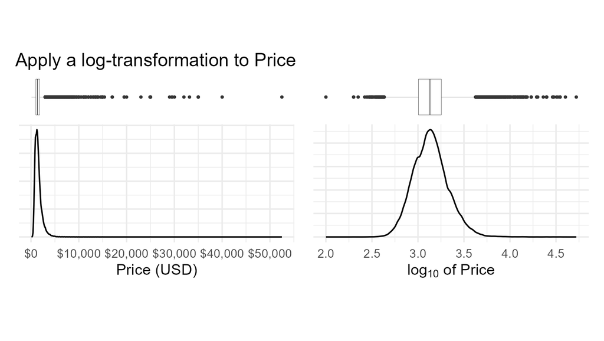

Figure 1: Inspect the distribution of the target variable on the original and log-transformed scales.

A thorough exploratory data analysis (EDA) was performed on a subset of the data separate from what was used for model building. A more detailed discussion of these results is included in **Appendix: EDA.** The primary goal of this EDA was to inform additional steps in the advanced preprocessing recipes, and relationships were primarily explored between predictor variables. Trends in the original variables were studied to identify skewness, nonlinearity, and interaction terms to aid linear models. The viability of new variables, particularly through manipulating factor levels and indicator variables, was also examined as potential improvements for all models. However, no relationships between any of the predictor variables and the target variable were directly explored to avoid unintended issues of information leakage.

# Methods

This regression problem follows one iteration of a standard model development process. The entire dataset was partitioned into disjoint subsets for EDA, fitting models (with V-fold cross-validation resampling), and final model assessment. Six different model types were used, each with multiple variants of preprocessing complexity. The winning model was selected using Root Mean Square Error (RMSE), computed on the log-transformed scale, as the assessment metric.

## Data Splitting

To ensure representative and similar distributions in each subset of the data, every data splitting step was stratified by the target variable. The full cleaned dataset was first partitioned into an EDA dataset (containing about 2/3 of the data, or ~66,000 observations) and a modeling dataset (1/3 of the data, ~33,000 observations). Then, the modeling dataset was further split into training/testing sets using a 90/10 ratio, giving about 30,000 observations for training and 3,300 for testing. Resamples were formed on the training set using V-fold cross-validation with 10 folds and 5 repeats. Thus, each fold uses 9/10 of the training set (~27,000 observations) for training and 1/10 for assessment (~3,000 observations), and 50 estimates are averaged to produce one performance metric for each submodel.

## Model Types

This project uses 6 different model types: Null, Ordinary Least Squares, Elastic Net, K-Nearest Neighbors, Random Forest, and Boosted Tree. Each model type (besides the null model) was fitted to at least two variants of preprocessing recipes, and hyperparameter values were tuned using a regular grid on applicable model types (all models except for null and ordinary least squares). All models were fitted to 50 resamples of the training set using the folded data. A summary of the model training process is shown below in Table 2.

Table 2: Model Training Totals

| Model Type | Number of Models | Total Number of Trainings |
| --- | --- | --- |
| Null | **1** | **50** |
| Ordinary Least Squares | **2** | 2 $\times$ 50 = **100** |
| Elastic Net | 20 $\times$ 11 $\times$ 2 = **440** | 440 $\times$ 50 = **22,000** |
| K-Nearest Neighbors | 25 $\times$ 4 = **100** | 100 $\times$ 50 = **5,000** |
| Random Forest | 4 $\times$ 3 $\times$ 4 $\times$ 2 = **96** | 96 $\times$ 50 = **4,800** |
| Boosted Tree | 3 $\times$ 4 $\times$ 3 $\times$ 10 $\times$ 2 = **720** | 720 $\times$ 50 = **36,000** |
| **Total** | **1,359** | **67,950** |

**Null Model:** The null model is the simplest baseline model, predicting every point as the average from the training data. While specifying a recipe is still necessary to follow the form of a standard workflow, this does not have any actual impact on the results (since this is a noninformative model). Thus, the null model was only fitted with the baseline linear recipe.

**Ordinary Least Squares (OLS):** This basic linear regression model estimates the best coefficients for the linear combination of predictors to predict the outcome variable. The OLS method seeks to minimize the sum of squared residuals from each prediction. This is a mechanistic, parametric model that explicitly follows an equation for linear regression. The OLS model was fitted with the baseline and advanced linear recipes, and the basic OLS model also serves as a slightly improved baseline over the null model.

**Elastic Net:** This penalized regression model uses a similar procedure as OLS with an additional penalty term added to the minimization. This is also a mechanistic, parametric model, but the interpretations are slightly more difficult due to added complexity from the penalty. Hyperparameters describing the scaling factor for penalty (`penalty`) and the proportion of Lasso/Ridge penalty (`mixture`) were tuned. The elastic net models were fitted with the baseline and advanced linear recipes.

**K-Nearest Neighbors (KNN):** This data-driven, nonparametric model predicts the value for each point by averaging the $k$ points that are most similar by a measure of “closeness” in the predictors. The value of $k$ is tuned through the `neighbors` hyperparameter. The KNN model was fitted with the baseline and advanced recipes using both linear and tree-based variants.

**Random Forest:** This tree-based ensemble model creates many independent decision trees that each split the data along a number of randomly selected predictors. Predictions are made by averaging the endpoints across all decision trees in the random forest. This is a data-driven, nonparametric model. Hyperparameters describing the number of randomly selected predictors (`mtry`), total number of trees (`trees`), and size of each endpoint node (`min_n`) were tuned. The random forest models were fitted with the baseline and advanced tree-based recipes.

**Boosted Tree:** This tree-based ensemble model is similar to the random forest, but decision trees are fit sequentially instead of independently. The value for each point is predicted by combining the results from all trees in a weighted sum. This is also a data-driven, nonparametric model. The same hyperparameters as the random forest were tuned, as well as the amount of influence each sequential tree has from prior trees (`learn_rate`). The boosted tree models were fitted with the baseline and advanced tree-based recipes.

## Recipes

This project uses 2 levels of recipe complexity (baseline and advanced). Each recipe type also has a linear and tree-based variant to optimize preprocessing based on the requirements of different model types that were fitted.

**Baseline Recipe:** This basic recipe only included the minimal necessary preprocessing to build an informative model. The target variable was predicted using all other (reasonable) variables. Steps were included to impute missing values (using a linear method), dummy encode factor variables, remove low variance predictors, and center and scale all predictors. The linear and tree-based variants were very similar, and the only difference was using one-hot encoding for factor variables in the tree-based recipe.

**Advanced Tree-Based Recipe:** This advanced recipe included some additional steps beyond the minimal preprocessing from the baseline recipe. The primary changes were from creating new variables (informed by EDA) since tree-based models intrinsically capture nonlinearity and interactions in predictors. Imputation was also changed to only use numeric variables (but still a linear method), and one-hot encoding was used for this tree-based recipe.

Some variables that were omitted in the baseline recipe were recovered by manipulating factor levels. States were recoded into regions (as defined by the [U.S. Bureau of Economic Analysis](https://www.bea.gov/)), and different source websites were collapsed into an “Other” category. New predictors were also created, detecting exclamation points in the title and body text of a listing and computing ratios between bedrooms, square feet, and bathrooms. Additionally, similar amenities were grouped into categories and counted, along with a count of total amenities. Then, only the top 11 standalone amenities (all found in over 15% of observations) were preserved.

**Advanced Linear Recipe:** This advanced recipe included the changes from the advanced tree-based recipe, as well as additional steps to help the linear methods capture more complex relationships. A $\log_{10}$ transformation was used on square feet since it displayed a strong right skew. Interaction terms (informed by EDA) were introduced between square feet and bedrooms, bathrooms, and the bedroom/bathroom ratio, as well as between and within the amenities groups. Natural splines were also used to capture the nonlinearity that was observed in latitude and longitude. The minimal preprocessing steps were still included, with imputation similarly using only numeric variables and normal (not one-hot) encoding for factor variables.

# Model Selection

The model comparison metric for this regression problem was RMSE (on the $\log_{10}$ scale) which quantifies the typical error in a prediction. Lower RMSE values correspond to better performance, and the best performing models for each model type are shown below in Table 3 and Figure 2. Complete results for all fitted models are included in **Appendix: Full Model Rankings.** Based on these results, the best model type was the baseline boosted tree, having the lowest value for RMSE by multiple standard errors.

Table 3: Comparison of Best Models

|  | Model Type | RMSE (mean) | RMSE (se) | n | Hyperparameter Values |
| --- | --- | --- | --- | --- | --- |
| 1 | Boosted Tree (baseline recipe) | 0.07173646027417518 | 0.000246097163406905 | 50 | mtry = 25, trees = 700, min_n = 2, learn_rate = 0.1848 |
| 2 | Boosted Tree (advanced recipe) | 0.0722512538302848 | 0.0002396782886394296 | 50 | mtry = 40, trees = 700, min_n = 2, learn_rate = 0.1848 |
| 3 | Random Forest (baseline recipe) | 0.07755419978100876 | 0.0002429025791958694 | 50 | mtry = 17, trees = 700, min_n = 2 |
| 4 | Random Forest (advanced recipe) | 0.07930596776212902 | 0.000256633520843828 | 50 | mtry = 27, trees = 700, min_n = 2 |
| 5 | K-Nearest Neighbors (advanced linear recipe) | 0.1210636927972295 | 0.0002653174025564945 | 50 | neighbors = 11 |
| 6 | Ordinary Least Squares (advanced recipe) | 0.1284656484475107 | 0.0003116825722937179 | 50 | N/A |
| 7 | Elastic Net (advanced recipe) | 0.1285851703166422 | 0.000315565901107078 | 50 | penalty = 0, mixture = 0.8 |
| 8 | K-Nearest Neighbors (advanced tree recipe) | 0.1297052312925695 | 0.000247396613265102 | 50 | neighbors = 15 |
| 9 | K-Nearest Neighbors (baseline linear recipe) | 0.1412856286506087 | 0.0002949727739321405 | 50 | neighbors = 13 |
| 10 | K-Nearest Neighbors (baseline tree recipe) | 0.1421652587594858 | 0.0002761717432174893 | 50 | neighbors = 13 |

[output cut: 3 more lines]

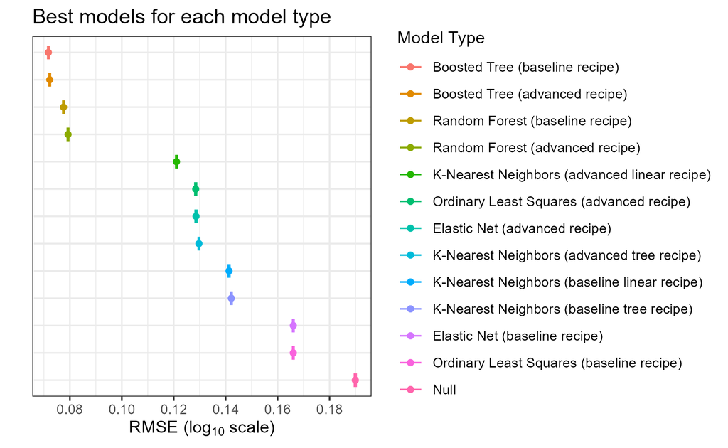

Figure 2: Compare the best models for each model type using RMSE.

Among the baseline boosted tree models, there were two submodels with comparable performance with RMSE values within one standard error of each other (Table 4). Between these two models, the only difference was in the number of randomly selected predictors (`mtry`), and both have similar complexities. Thus, the winning model was simply selected as the slightly better performing one (row 1 in Table 4).

Table 4: Best Baseline Boosted Tree Models

|  | Hyperparameter Values | RMSE (mean) | RMSE (se) | n |
| --- | --- | --- | --- | --- |
| 1 | mtry = 25, trees = 700, min_n = 2, learn_rate = 0.1848 | 0.07173646027417518 | 0.000246097163406905 | 50 |
| 2 | mtry = 13, trees = 700, min_n = 2, learn_rate = 0.1848 | 0.0718277285228168 | 0.0002386245886841986 | 50 |

## Model Type/Recipe Analysis

Overall, it is not surprising that the boosted tree models were the best. data-driven models typically have better performance in predictive problems since they are more flexible than mechanistic models, and thus they can capture more intricate relationships easily. The random forest models were second best, and Figure 2 shows that the two tree-based model types significantly outperformed all other model types.

The two baseline models (null, baseline OLS) were the worst performing, having RMSE values greater than the best models by about 0.1 on the $\log_{10}$ scale. This is a sizable difference relative to the overall values for RMSE that are all less than 0.2, indicating that it is worthwhile to develop the more complex models. In particular, it appears more useful to develop a simpler tree-based model than a more complex linear model, as the advanced linear models were still outperformed significantly by the basic tree-based models.

Interestingly, the advanced recipe did not improve, and even worsened, performance for the tree-based models. One potential explanation of this result is that the advanced recipe combines a lot of information (especially in amenities) while removing many of the original indicator variables. This was originally hypothesized as a reasonable improvement to consolidate similar information for each apartment, but it removes some more intricate relationships between individual amenities. Thus, in a tree-based model that can capture these interactions, this change may have actually hindered performance, and it would be interesting to compare the results when retaining all original variables.

The advanced recipes marked a major improvement for the linear and KNN models. Unlike tree-based models, these model types struggle to directly capture complex relationships between predictors, so it was useful to manually specify terms for interactions and nonlinearity. The grouping and removal of individual amenities was also likely helpful in this case, as the sheer number of original amenities variables (relative to the other predictors) artificially gives these more weight when making predictions. Figure 2 shows that these improvements are very significant, especially in the OLS and elastic net models where RMSE decreases by nearly 0.04 with the advanced recipe.

## Tuning Parameter Analysis

The best tuning parameter combinations for each model type are displayed in Table 3, and a more detailed discussion of tuning results is included in **Appendix: Tuning Parameter Analysis.** Overall, the tuning process was completed with no major issues, and the best hyperparameter values were approximated relatively successfully.

The elastic net models seem to favor very small amounts of penalty, giving more similar results to the OLS models in the best case. The KNN models show a clear minimum in RMSE, and the optimal number of neighbors is relatively similar between all recipe variants (slightly greater than 10). The tree-based models perform best with the maximum number of trees and smallest node size, as well as with a relatively large number of randomly selected predictors. These results are generally unsurprising, and the values correspond to capturing more intricate relationships in the data that is possible with a larger dataset for training. Further tuning could be explored to identify the best values at a higher level of precision, and other model or recipe parameters could also be considered in a second iteration of tuning.

# Final Model Analysis

The winning baseline boosted tree model from Table 4 was fitted to the entire training set, and its predictive performance was assessed on the testing set. Performance metrics of RMSE, Mean Absolute Error (MAE), Coefficient of Determination (R<sup>2</sup>), and Mean Absolute Percent Error (MAPE) were computed on both the $\log_{10}$ and original price scales based on the model’s predictions, and the results are shown in Table 5.

Table 5: Final Model Performance Metrics

| Metric | Log Scale | Original Scale |
| --- | --- | --- |
| RMSE | 0.0695 | 338 |
| MAE | 0.0491 | 175 |
| R<sup>2</sup> | 0.860 | 0.814 |
| MAPE | 1.57 | 11.5 |

Overall, the model appears very successful when considering results on the $\log_{10}$ scale. RMSE and MAE both quantify the average predictive error (with differing penalties for larger misses), and the values of 0.0695 and 0.0491 correspond to very small quantities compared to the typical values for log-transformed price in Figure 1. One particularly notable result was that this final RMSE value is lower than the out-of-sample estimate from resampling by multiple standard errors, so it is unlikely that the model is overfitting. The R<sup>2</sup> value indicates that 86.0% of the variability in price is explained by the model, and the MAPE value states that each predictive error is about 1.57% on average, further suggesting that this is a very successful model.

The model performs slightly worse on the original scale, but the results are still reflective of a good predictive model. The RMSE and MAE values are $338 and $175 respectively, representing larger errors relative to the values for price (centered at about $1,500). The R<sup>2</sup> and MAPE values are also worse than on the $\log_{10}$ scale, with the model explaining about 81.4% of the variability in price and an average prediction error of about 11.5%. Nonetheless, these are still fairly impressive results that characterize a successful model overall. Importantly, this final model significantly outperforms the simplest null and baseline linear models, showing that the model building process was worthwhile.

Figure 3 also shows the predictive performance of the model on both the $\log_{10}$ and original scales. Most points appear to be very close to the dashed line that indicates a perfect prediction, and there are very few points that deviate significantly with a major error. There also is a clear tendency to predict extreme prices closer to the average, with more underpredictions of larger prices and overpredictions of smaller prices. However, that is reasonable to observe due to the nature of how data-driven models are trained, where each prediction is influenced by other similar observations in the dataset. Thus, Figure 3 further confirms the assessment of the final model as a successful model.

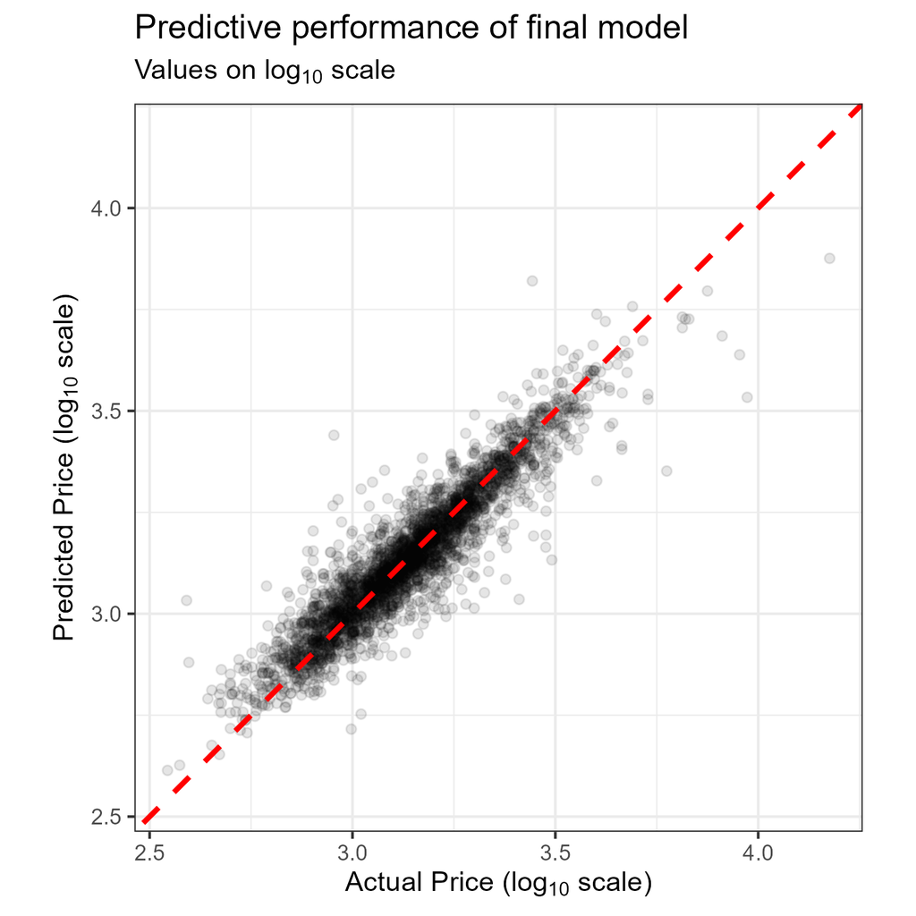

(a) Log Scale

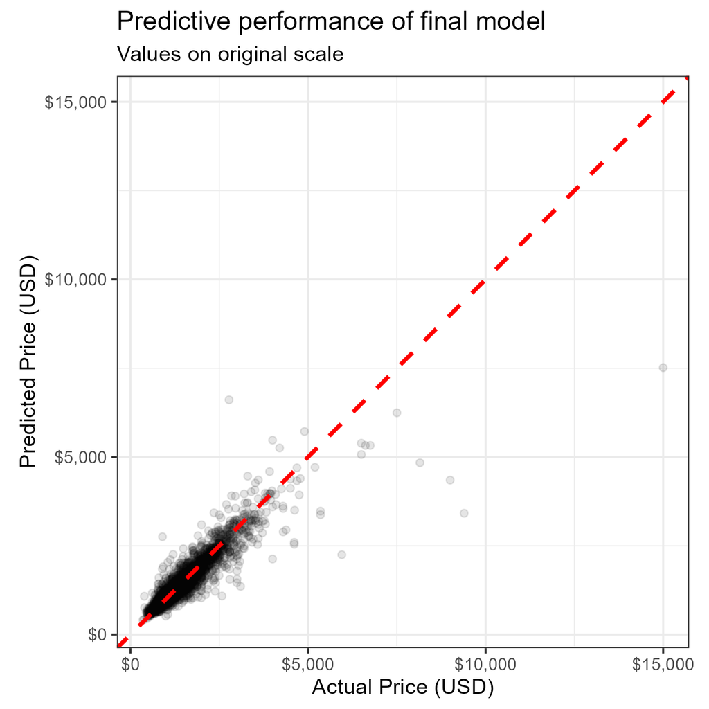

(b) Original Scale

Figure 3: Visualize predicted and actual values from the final model on both the log-transformed and original scales.

# Conclusion

Overall, this project successfully implemented the model development process to predict prices of apartments in the United States. Among the 13 overall model types that were fitted, the baseline boosted tree was selected as the best performing model. This final model was assessed on a testing set of about 3,000 new observations, performing very well with relatively small typical errors and explaining over 80% of the variance in the target variable. The best model also significantly outperformed the simplest baseline models, indicating that it was worthwhile to develop more complex predictive models.

One notable result was that the advanced tree-based models did not improve upon their baseline counterparts (and even performed worse). While the advanced recipe was designed as an improvement that included new variables, the removal of original indicator variables likely counteracted that change. Thus, one relatively simple exploration would be to develop a new recipe that retains those variables and compare results, and I expect the new advanced models to improve and potentially beat the winning model from this project. Additional recipe variants could also be developed to isolate the effects of individual variables by comparing results with and without those predictors in a more targeted analysis.

Other directions for future work center around performing another iteration of the model development process. While there were no major issues in tuning hyperparameters, and the best values were roughly located using a regular grid, further tuning could be useful to improve the precision of these values. That is not as important for this exact project, but a real-world model would likely seek to continue improving model performance since even small gains can lead to major profits. Because there is not much practical use of this model, I am unlikely to continue with that direction. However, this was still a very interesting and insightful project for applying the model development process to a relevant topic, and the final model was very successful despite only using relatively basic machine learning techniques.

# References

Apartment for Rent Classified [Dataset]. (2019). UCI Machine Learning Repository. https://doi.org/10.24432/C5X623. [Link to data](https://archive.ics.uci.edu/dataset/555/apartment+for+rent+classified), published December 25, 2019; downloaded January 29, 2025.

Regions for states defined according to [U.S. Bureau of Economic Analysis](https://www.bea.gov/).

# Comment on Generative AI

I used AI as a tool for some more tedious and tricky tasks, such as less common data-wrangling techniques to build nicer figures and tables. While I sometimes directly used code that was generated by AI, I always checked it manually and made the necessary adjustments to better fit my intentions, and I also clearly noted sections that used AI in my code. This was limited to relatively minor steps. I used both Microsoft Copilot and ChatGPT, as well as non-AI assistance from Stack Overflow.

# Appendix: EDA

This section contains figures for the most informative EDA results that were implemented in the advanced recipes. Other explorations that were not ultimately included in the advanced recipes are not shown here. Both advanced recipes incorporated new variables, while the linear recipe also explored ways to capture nonlinearity and interactions.

## Both Advanced Recipes

**State to Region:** Figure 4 shows the transformation of states into regions to reduce the number of factor levels. Each color represents the contribution of an individual state, and there were many states with an unusably small number of observations. This transformation creates a new predictor variable that is much better distributed.

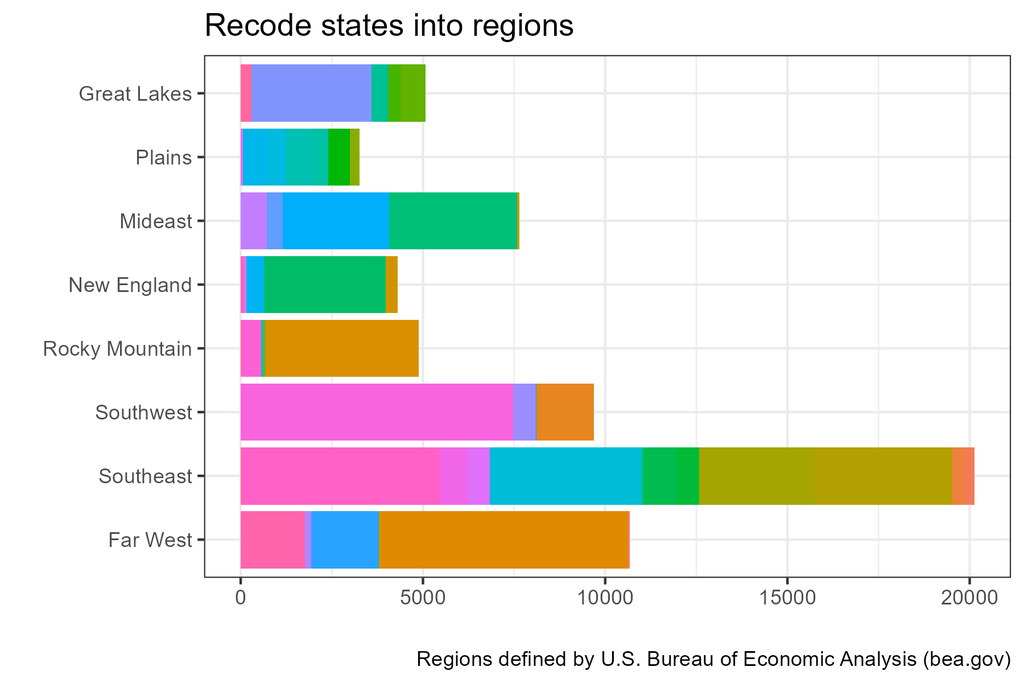

Figure 4: Consider the distribution when using regions instead of states.

**Collapse Source Levels:** Figure 5 shows the result after collapsing miscellaneous source levels into an “Other” category. Initially, there were many smaller levels that rendered this variable essentially useless. There is still significant imbalance after this transformation, but this introduces a potential new predictor variable. The near-zero variance filter also serves as a preventative measure against imbalance-related issues during fitting.

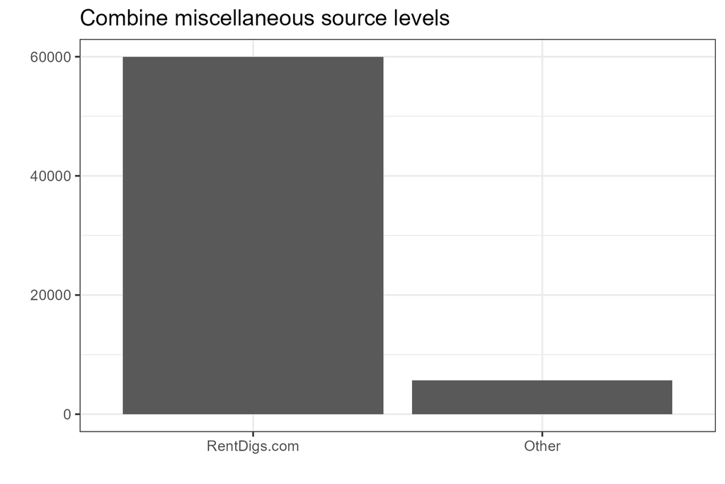

Figure 5: Consider the distribution of source levels after combining into an “Other” category.

**Bedroom/Bathroom Ratio:** Figure 6 shows the result from computing bedroom/bathroom ratios. This was tested using both a continuous (numeric) and discrete method, and the discretized result was used due to the grouping of many points at common values. This transformation creates a new predictor variable based on two original predictors. Note: Missing values are imputed during preprocessing and thus end up in one of the four other categories.

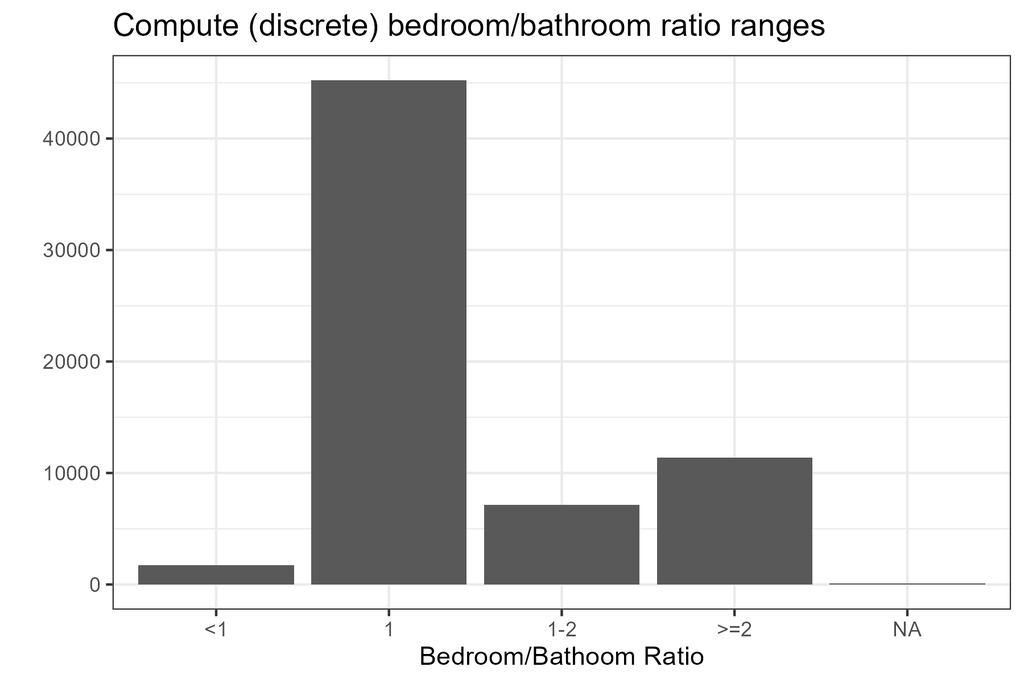

Figure 6: Compute the (discretized) ratio of bedrooms to bathrooms as a potential new predictor variable.

**Square Feet/Bedroom Ratio:** Figure 7 shows the result from computing square feet/bedroom ratios. This transformation creates a new predictor variable based on two original predictors. While there appears to be some right-skew in this new variable, the skew is not problematic and no log-transformation was used.

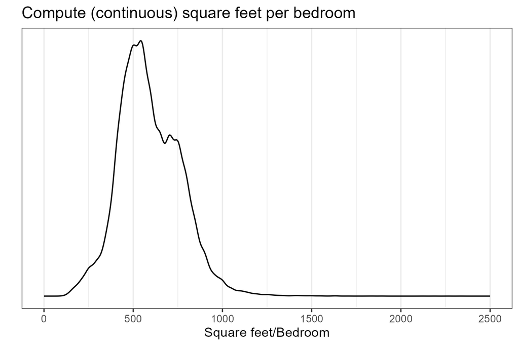

Figure 7: Compute the ratio of square feet per bedroom as a potential new predictor variable.

**Number of Amenities:** Figure 8 shows the result from counting the total number of amenities. This transformation creates a new predictor variable based on all of the amenities columns. The information from those indicator variables is consolidated into a single numeric variable using the sum, although some of the original columns are still retained as individual predictors.

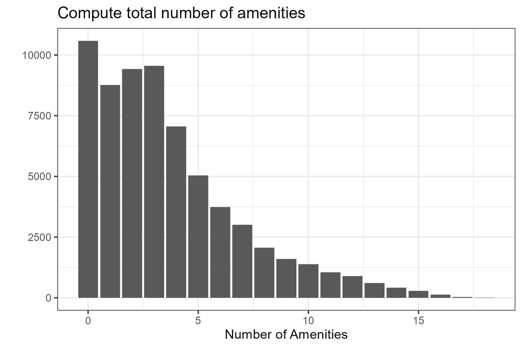

Figure 8: Compute the total number of amenities as a potential new predictor variable.

**Amenities Groups:** Figure 9 shows the result from grouping similar amenities into category scores (appliances, electronics, misc, premium, recreation, safety). This transformation creates new predictor variables based on the corresponding amenities columns. The information from those indicator variables is consolidated into new numeric variables using the sum, although some of the original columns are still retained as individual predictors.

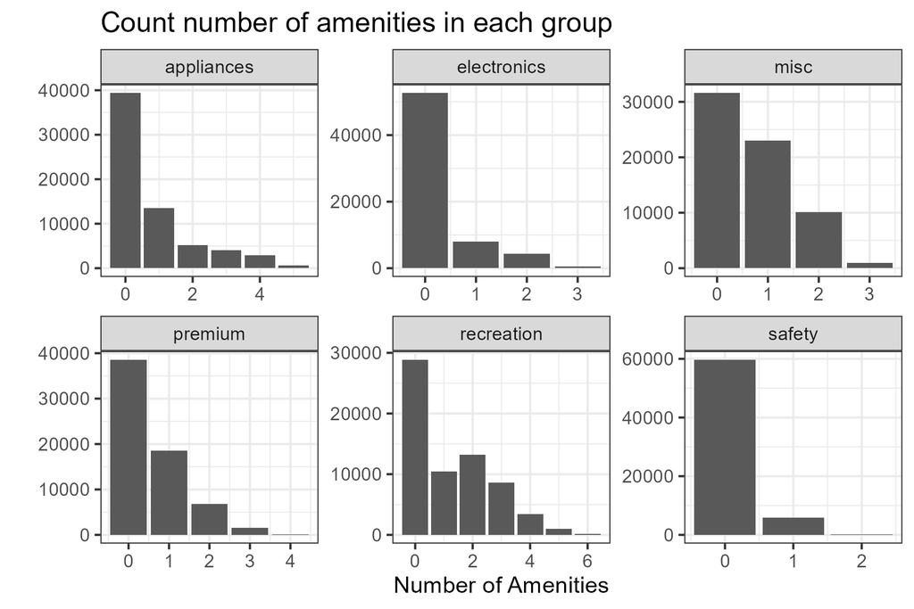

Figure 9: Compute the number of amenities within each grouping as potential new predictor variables.

**Exclamation Points:** Figure 10 shows the result from detecting exclamation points in the title and body of an apartment listing. This transformation creates two new predictor variables from information that was otherwise difficult to incorporate. The distribution across the different levels is also much more usable than when extracting other strings.

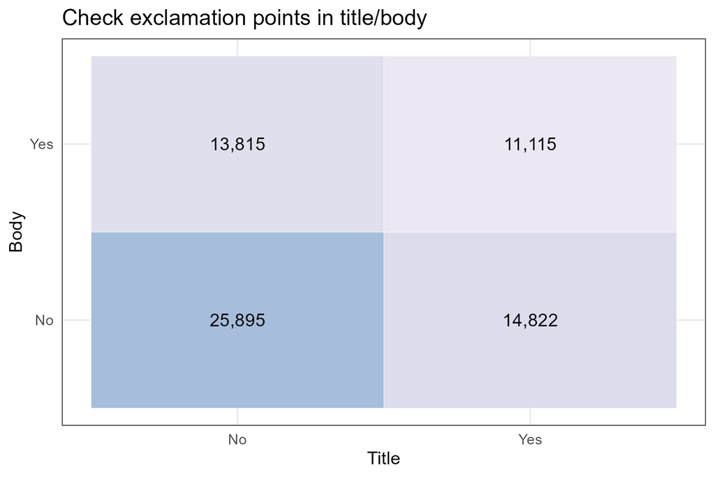

Figure 10: Consider the presence of exclamation points in the title and body as a potential new predictor variable.